# Stroke Dataset Exploration:

## by: A'isha Ahmad Mahmoud Eshra

## Investigation Overview

> What are the main features causing Stroke?

> This dataset is used to predict whether a patient is likely to get stroke based on the input parameters like gender, age, various diseases, and smoking status. Each row in the data provides relavant information about the patient.

## Dataset Overview

> According to the World Health Organization (WHO) stroke is the 2nd leading cause of death globally, responsible for approximately 11% of total deaths.

## Age

> Most of the patients who had experienced a Stroke in our dataset are seniors or Adults as showen in the graph below:

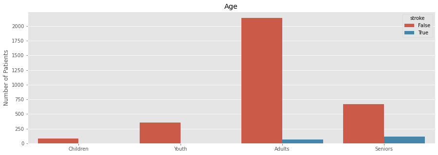

## Age-Weight-Gender

> as we said before and is showen in the figure above seniors are more likely to have a stroke; and this probabilty increses if they were Obese or over weighted and more likely for people in their late 60s (males and females) as showen here:

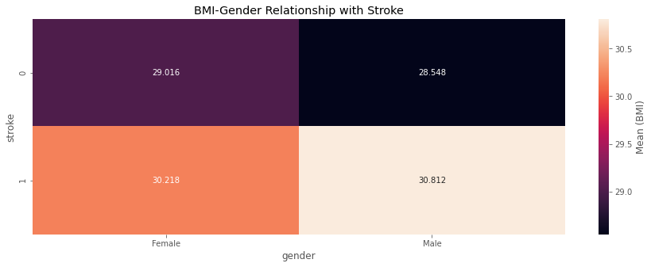

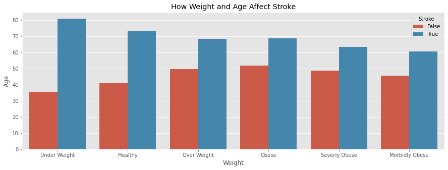

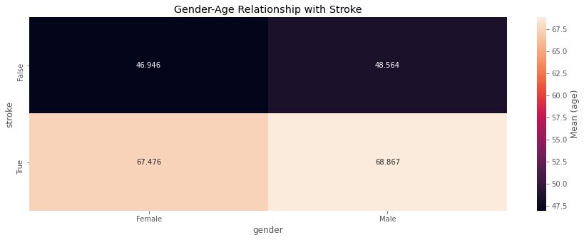

## Diseases

> Different diseases affect stroke as we can confirm next that smokers with high blood suger in addition to hypertension and heart disease history are more likely to have a stroke.

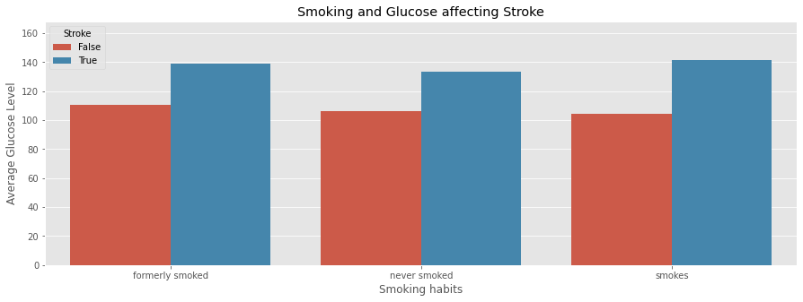

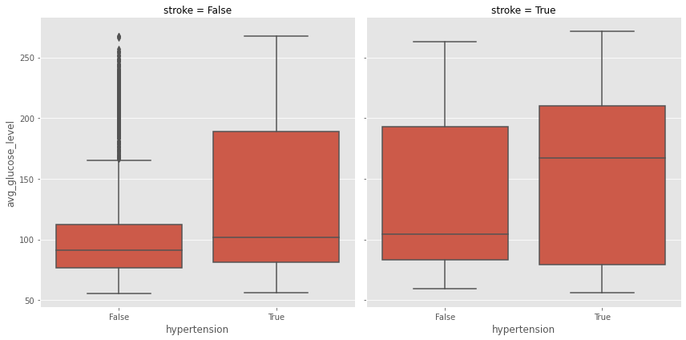

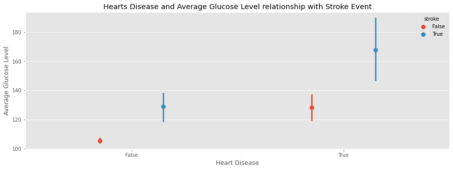

## Conclusion:

> As a final conclusion we can state that several variables are affecting have a stroke like diseases history (Suger, Heart Diseases or hypertension) in addition to bad habits like smoking or unhealthy food .. and the natural effect of aging.